# ISI final assignment: Life on a forum - User Demographics and behaviour

Tim Munters, Bert Van Poeck

https://github.com/jebewa/Notebook-Life-on-a-Forum

### Libraries and packages

```python
import mysql.connector
import getpass
from IPython.display import display
import pandas as pd
import matplotlib.pyplot as plt
import json
import numpy as np
```

- the age distribution of the users on the statistic forum
- the possible correlation between the age of users and the amount of comments they post
- the possible correlation between the age of users and the length of comments they post
- the possible correlation between the age of users and the amount of submitted posts
- the geographical distribution of users per age group

## Different age groups and their size

```python
sql_query2 ="""
SELECT SUM(CASE WHEN Age < 9 THEN 1 ELSE 0 END) AS 'Under 9',
        SUM(CASE WHEN Age Between 10 AND 19 THEN 1 ELSE 0 END) AS '10-19',
        SUM(CASE WHEN Age BETWEEN 20 AND 29 THEN 1 ELSE 0 END) AS '20-29',
        SUM(CASE WHEN Age BETWEEN 30 AND 39 THEN 1 ELSE 0 END) AS '30-39',
        SUM(CASE WHEN Age BETWEEN 40 AND 49 THEN 1 ELSE 0 END) AS '40-49',
        SUM(CASE WHEN Age BETWEEN 50 and 59 THEN 1 ELSE 0 END) AS '50-59',
        SUM(CASE WHEN Age BETWEEN 60 and 69 THEN 1 ELSE 0 END) AS '60-69',
        SUM(CASE WHEN Age BETWEEN 70 and 79 THEN 1 ELSE 0 END) AS '70-79',
        SUM(CASE WHEN Age BETWEEN 80 and 89 THEN 1 ELSE 0 END) AS '80-89',
        SUM(CASE WHEN Age BETWEEN 90 and 99 THEN 1 ELSE 0 END) AS '90-99'
FROM users
"""
```

```python
df1 = pd.read_sql(sql_query2, conn)
df1.head()
```

|  | Under 9 | 10-19 | 20-29 | 30-39 | 40-49 | 50-59 | 60-69 | 70-79 | 80-89 | 90-99 |
| --- | --- | --- | --- | --- | --- | --- | --- | --- | --- | --- |
| 0 | 0.0 | 114.0 | 3951.0 | 3177.0 | 764.0 | 188.0 | 51.0 | 17.0 | 2.0 | 54.0 |

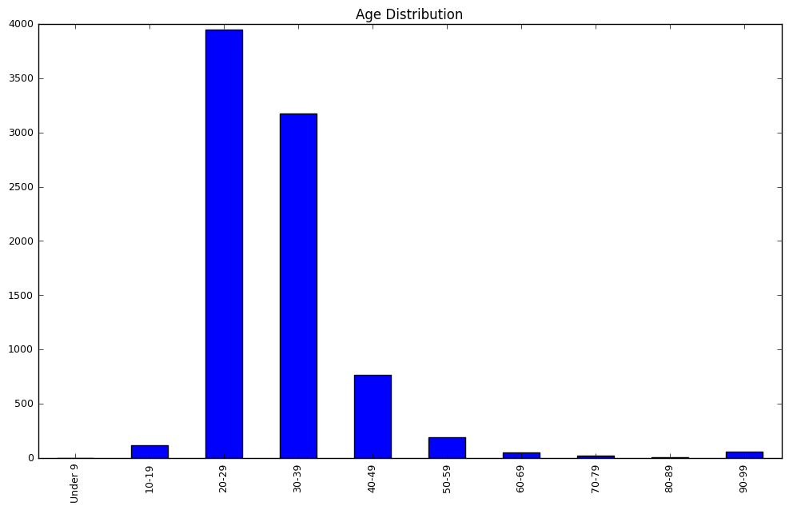

```python
plt.figure()
ax1 = df1[[0]].plot(kind='bar', title ="Age Distribution", figsize=(12, 7), legend=False,
fontsize=9)
plt.show()
```

## Age and the amount of commenting

In the following subsection we will examine the data to establish whether there is a correlation between the age of users and their commenting habits:

- how often do users within a given age group comment
- how long is the average comment per age group

```python
sql_queryage_comments ="""
SELECT COUNT(DISTINCT Text) AS AmountOfComments, SUM(CASE WHEN Age < 9 THEN 1 ELSE 0 END) AS 'Under 9', SUM(CASE WHEN Age Between 10 AND 19 THEN 1 ELSE 0 END) AS '10-19', SUM(CASE WHEN Age BETWEEN 20 AND 29 THEN 1 ELSE 0 END) AS '20-29', SUM(CASE WHEN Age BETWEEN 30 AND 39 THEN 1 ELSE 0 END) AS '30-39', SUM(CASE WHEN Age BETWEEN 40 AND 49 THEN 1 ELSE 0 END) AS '40-49', SUM(CASE WHEN Age BETWEEN 50 and 59 THEN 1 ELSE 0 END) AS '50-59', SUM(CASE WHEN Age BETWEEN 60 and 69 THEN 1 ELSE 0 END) AS '60-69', SUM(CASE WHEN Age BETWEEN 70 and 79 THEN 1 ELSE 0 END) AS '70-79', SUM(CASE WHEN Age BETWEEN 80 and 89 THEN 1 ELSE 0 END) AS '80-89', SUM(CASE WHEN Age BETWEEN 90 and 99 THEN 1 ELSE 0 END) AS '90-99'
FROM users, comments
WHERE comments.UserId = users.Id
"""
```

```python
df2 = pd.read_sql(sql_queryage_comments, conn)
df2.head()
```

|  | AmountOfComments | Under 9 | 10-19 | 20-29 | 30-39 | 40-49 | 50-59 | 60-69 | 70-79 | 80-89 | 90-99 |
| --- | --- | --- | --- | --- | --- | --- | --- | --- | --- | --- | --- |
| 0 | 170773 | 0.0 | 22764.0 | 13368.0 | 16410.0 | 7097.0 | 5486.0 | 2931.0 | 690.0 | 3.0 | 64.0 |

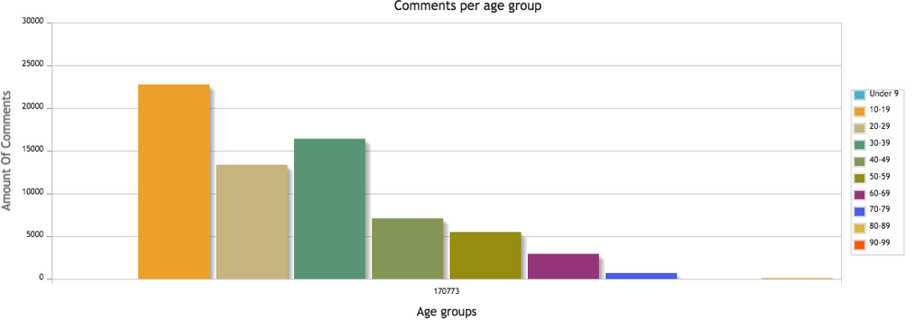

```python
from IPython.display import Image
Image(filename="comment_plot.png")
```

```python
sql_queryage_specific = """SELECT UserId, Displayname, COUNT(DISTINCT Text) AS AmountOfComments, Age
FROM comments, users
WHERE comments.UserId = users.Id AND Age BETWEEN 10 and 19
GROUP BY Age
ORDER BY AmountOfComments
"""
```

```python
df90 = pd.read_sql(sql_queryage_specific, conn)
df90=df90.T
df90.head()
```

|  | 0 | 1 | 2 | 3 | 4 | 5 | 6 |
| --- | --- | --- | --- | --- | --- | --- | --- |
| UserId | 44114 | 25363 | 14062 | 297 | 7828 | 805 | 919 |
| Displayname | Anubian Noob | Emrakul | Claudio Albertin | Maxim Zaslavsky | Anony-Mousse | Glen_b | whuber |
| AmountOfComments | 1 | 30 | 32 | 46 | 591 | 8786 | 13237 |
| Age | 15 | 18 | 19 | 17 | 16 | 13 | 14 |

A next part will investigate this phenomenon where a small group of users posts an incredible amount of comments. With a scatterplot we will try to combine the amount of comments with the amount of commenters per age.

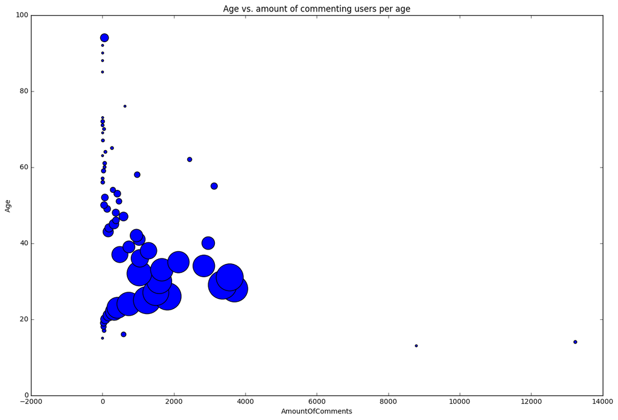

```python
df50.plot.scatter(x='AmountOfComments', y='Age', s=df50['AmountOfUsers'] * 10, figsize=(15,10), title='Age vs. amount of commenting users per age')
plt.show()
```

It would be unwise to assume that all these comments would have the same length. Perhaps top commenters only post short comments and are therefore able to post the amount of comments they submit. Another scatterplot will look at the average length of these comments per age group.

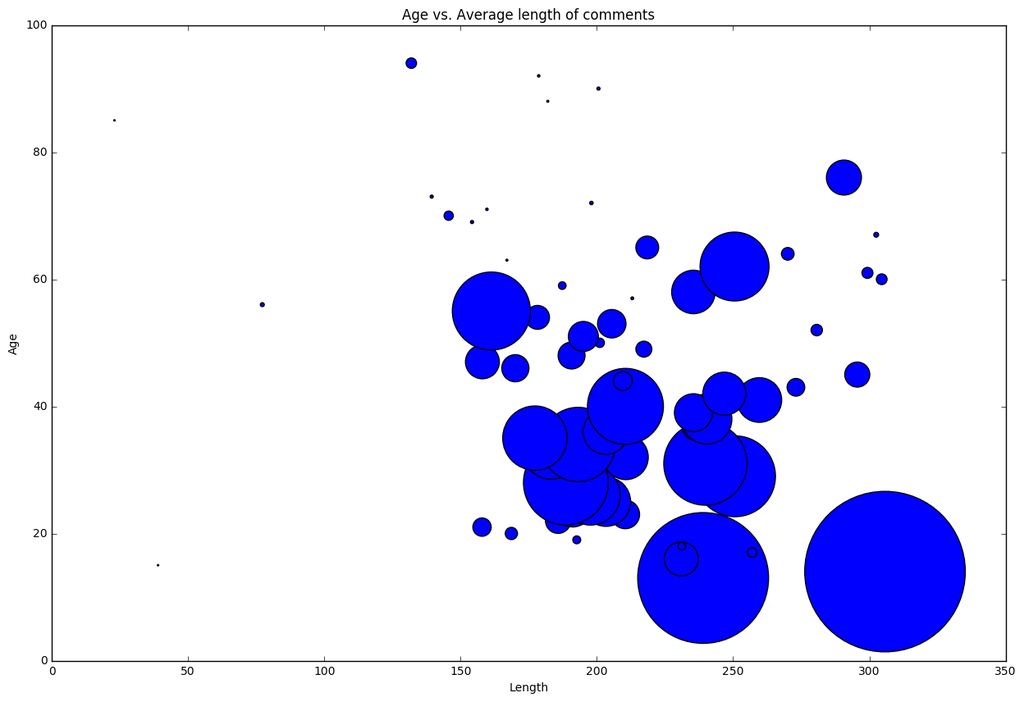

```python
df55.plot.scatter(x='Length', y='Age', s=df55['AmountOfComments'] * 1.5, figsize=(15,10), title='Age vs. Average length of comments')
plt.show()
```

## Age and amount of posts

In the following subsection we will examine the data to establish whether there is a correlation between the age of users and their posting habits:

- how often do users within a given age group submit posts

```python
sql_query_post ="""SELECT COUNT(DISTINCT Body) AS AmountOfPosts, SUM(CASE WHEN Age < 9 THEN 1 ELSE 0 END) AS 'Under 9', SUM(CASE WHEN Age Between 10 AND 19 THEN 1 ELSE 0 END) AS '10-19', SUM(CASE WHEN Age BETWEEN 20 AND 29 THEN 1 ELSE 0 END) AS '20-29', SUM(CASE WHEN Age BETWEEN 30 AND 39 THEN 1 ELSE 0 END) AS '30-39', SUM(CASE WHEN Age BETWEEN 40 AND 49 THEN 1 ELSE 0 END) AS '40-49', SUM(CASE WHEN Age BETWEEN 50 and 59 THEN 1 ELSE 0 END) AS '50-59', SUM(CASE WHEN Age BETWEEN 60 and 69 THEN 1 ELSE 0 END) AS '60-69', SUM(CASE WHEN Age BETWEEN 70 and 79 THEN 1 ELSE 0 END) AS '70-79', SUM(CASE WHEN Age BETWEEN 80 and 89 THEN 1 ELSE 0 END) AS '80-89', SUM(CASE WHEN Age BETWEEN 90 and 99 THEN 1 ELSE 0 END) AS '90-99'
FROM users, posts
WHERE posts.OwnerUserId = users.Id"""
```

```python
df3 = pd.read_sql(sql_query_post, conn)
df3.head()
```

|  | AmountOfPosts | Under 9 | 10-19 | 20-29 | 30-39 | 40-49 | 50-59 | 60-69 | 70-79 | 80-89 | 90-99 |
| --- | --- | --- | --- | --- | --- | --- | --- | --- | --- | --- | --- |
| 0 | 90350 | 0.0 | 3402.0 | 6901.0 | 8825.0 | 3717.0 | 2637.0 | 826.0 | 456.0 | 0.0 | 40.0 |

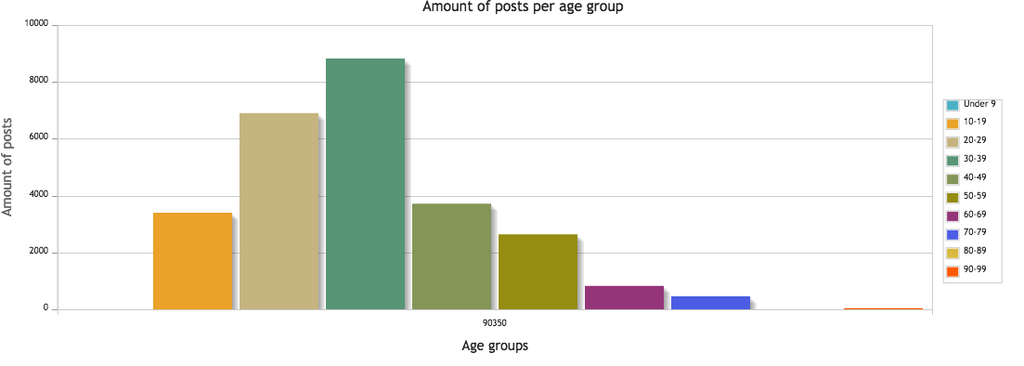

```python
from IPython.display import Image
Image(filename="post_plot.png")
```

## Users and their geographical location

In the following subsection we will examine the geographical distribution of the users on the forum.

```python
sql_query4 ="""
SELECT count(*), Location FROM users WHERE Location is NOT NULL GROUP BY Location ORDER BY count(*) DESC
"""
```

```python
df5 = pd.read_sql(sql_query4, conn)
df5.head()
```

|  | count(*) | Location |
| --- | --- | --- |
| 0 | 352 | United States |
| 1 | 281 | London, United Kingdom |
| 2 | 222 | Germany |
| 3 | 209 | India |
| 4 | 209 | United Kingdom |

```python
sql_query5 ="""
SELECT COUNT(*), Location FROM `users` WHERE Location LIKE "%Belgium%" GROUP BY Location
"""
```

```python
df_belgium = pd.read_sql(sql_query5, conn)
df_belgium.head()
```

|  | COUNT(*) | Location |
| --- | --- | --- |
| 0 | 8 | Antwerp, Belgium |
| 1 | 1 | Antwerp/Leuven, Belgium |
| 2 | 71 | Belgium |
| 3 | 2 | Bruges, Belgium |
| 4 | 13 | Brussels, Belgium |

### Export of geographical location and textmining

```python
sql_query6 ="""
SELECT Location FROM users
WHERE Location IS NOT NULL
INTO OUTFILE 'C:\location.csv'"""
```

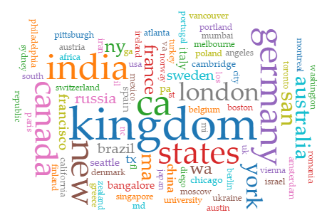

```python
from IPython.display import Image
Image(filename="frequent_locations.png")
```

```python
from IPython.display import HTML, display
display(HTML("<table><tr><td><p><b>10-19</p><img src='10-19.png'></td><td><p><b>20-29</p><img src='20-29.png'></td><td><p><b>30-39</p><img src='30-39.png'></td></tr></table>"))
display(HTML("<table><tr><td><p><b>40-49</p><img src='40-49.png'></td><td><p><b>50-59</p><img src='50-59.png'></td><td><p><b>60-69</p><img src='60-69.png'></td></tr></table>"))
```

[output not shown]

| **10-19** | **20-29** | **30-39** |
| --- | --- | --- |

| **40-49** | **50-59** | **60-69** |
| --- | --- | --- |

### Relative importance of users from India

```python
sql_query7 = """SELECT Location, SUM(CASE WHEN Age < 9 THEN 1 ELSE 0 END) AS 'Under 9',
        SUM(CASE WHEN Age Between 10 AND 19 THEN 1 ELSE 0 END) AS '10-19',
        SUM(CASE WHEN Age BETWEEN 20 AND 29 THEN 1 ELSE 0 END) AS '20-29',
        SUM(CASE WHEN Age BETWEEN 30 AND 39 THEN 1 ELSE 0 END) AS '30-39',
        SUM(CASE WHEN Age BETWEEN 40 AND 49 THEN 1 ELSE 0 END) AS '40-49',
        SUM(CASE WHEN Age BETWEEN 50 and 59 THEN 1 ELSE 0 END) AS '50-59',
        SUM(CASE WHEN Age BETWEEN 60 and 69 THEN 1 ELSE 0 END) AS '60-69',
        SUM(CASE WHEN Age BETWEEN 70 and 79 THEN 1 ELSE 0 END) AS '70-79',
        SUM(CASE WHEN Age BETWEEN 80 and 89 THEN 1 ELSE 0 END) AS '80-89',
        SUM(CASE WHEN Age BETWEEN 90 and 99 THEN 1 ELSE 0 END) AS '90-99'
FROM `users`
WHERE Location is not NULL
"""
```

```python
df55 = pd.read_sql(sql_query7, conn)
df55.head()
```

|  | Location | Under 9 | 10-19 | 20-29 | 30-39 | 40-49 | 50-59 | 60-69 | 70-79 | 80-89 | 90-99 |
| --- | --- | --- | --- | --- | --- | --- | --- | --- | --- | --- | --- |
| 0 | on the server farm | 0.0 | 90.0 | 3369.0 | 2858.0 | 715.0 | 172.0 | 49.0 | 14.0 | 1.0 | 54.0 |

```python
sql_query8 = """SELECT
        SUM(CASE WHEN Age < 9 THEN 1 ELSE 0 END) AS 'Under 9',
        (SUM(CASE WHEN Age Between 10 AND 19 THEN 1 ELSE 0 END) / 90.0 * 100) AS '10-19',
        (SUM(CASE WHEN Age BETWEEN 20 AND 29 THEN 1 ELSE 0 END) / 3369.0 * 100) AS '20-29',
        (SUM(CASE WHEN Age BETWEEN 30 AND 39 THEN 1 ELSE 0 END) / 2858.0 * 100) AS '30-39',
        (SUM(CASE WHEN Age BETWEEN 40 AND 49 THEN 1 ELSE 0 END) / 715.0 * 100) AS '40-49',
        (SUM(CASE WHEN Age BETWEEN 50 and 59 THEN 1 ELSE 0 END) / 172.0 * 100) AS '50-59',
        (SUM(CASE WHEN Age BETWEEN 60 and 69 THEN 1 ELSE 0 END) / 49.0 * 100) AS '60-69',
        (SUM(CASE WHEN Age BETWEEN 70 and 79 THEN 1 ELSE 0 END)  / 14.0 * 100) AS '70-79',
        (SUM(CASE WHEN Age BETWEEN 80 and 89 THEN 1 ELSE 0 END) / 1.0 * 100) AS '80-89',
        (SUM(CASE WHEN Age BETWEEN 90 and 99 THEN 1 ELSE 0 END) / 54.0 * 100) AS '90-99'
FROM `users`


WHERE Location LIKE "%india%"
"""
```

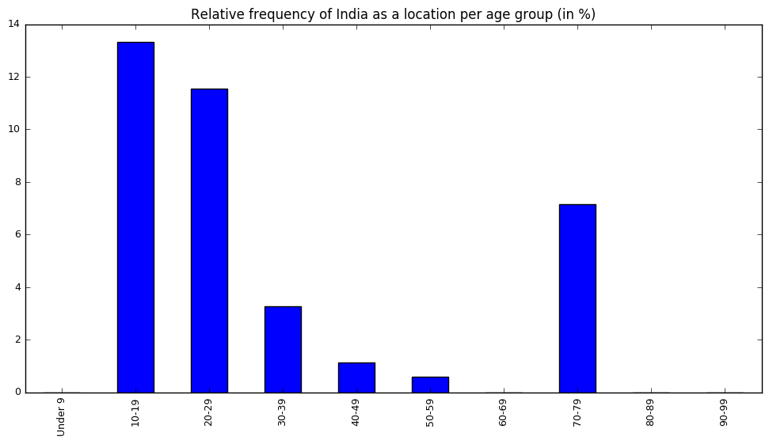

```python
plt.figure()
ax1 = df66[[0]].plot(kind='bar', title ="Relative frequency of India as a location per age group (in %)", figsize=(12, 6), legend=False,
fontsize=9)
plt.show()
```

```python
sql_query99 = """SELECT
        SUM(CASE WHEN Age < 9 THEN 1 ELSE 0 END) AS 'Under 9',
        (SUM(CASE WHEN Age Between 10 AND 19 THEN 1 ELSE 0 END) / 90.0 * 100) AS '10-19',
        (SUM(CASE WHEN Age BETWEEN 20 AND 29 THEN 1 ELSE 0 END) / 3369.0 * 100) AS '20-29',
        (SUM(CASE WHEN Age BETWEEN 30 AND 39 THEN 1 ELSE 0 END) / 2858.0 * 100) AS '30-39',
        (SUM(CASE WHEN Age BETWEEN 40 AND 49 THEN 1 ELSE 0 END) / 715.0 * 100) AS '40-49',
        (SUM(CASE WHEN Age BETWEEN 50 and 59 THEN 1 ELSE 0 END) / 172.0 * 100) AS '50-59',
        (SUM(CASE WHEN Age BETWEEN 60 and 69 THEN 1 ELSE 0 END) / 49.0 * 100) AS '60-69',
        (SUM(CASE WHEN Age BETWEEN 70 and 79 THEN 1 ELSE 0 END)  / 14.0 * 100) AS '70-79',
        (SUM(CASE WHEN Age BETWEEN 80 and 89 THEN 1 ELSE 0 END) / 1.0 * 100) AS '80-89',
        (SUM(CASE WHEN Age BETWEEN 90 and 99 THEN 1 ELSE 0 END) / 54.0 * 100) AS '90-99'
FROM `users`


WHERE Location LIKE "%kingdom%"

"""
```

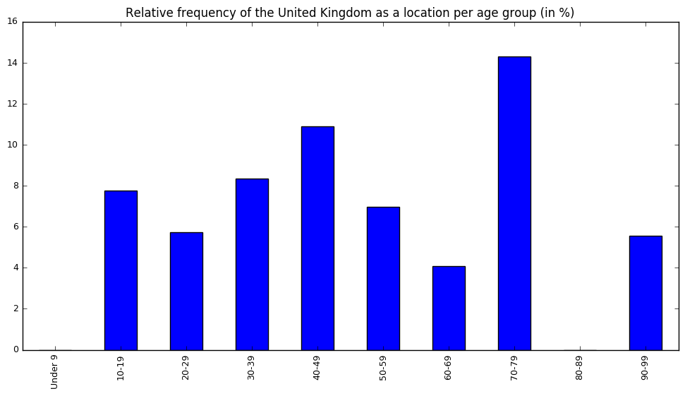

```python
plt.figure()
ax1 = df99[[0]].plot(kind='bar', title ="Relative frequency of the United Kingdom as a location per age group (in %)", figsize=(12, 6), legend=False,
fontsize=9)
plt.show()
```

### Comparison of the location similarity for the different age groups

- Export of Json-files from voyant
- Calculation of Jaccard Similarity Coefficient
- Filtering of nonsense-inputs

```python
df6 = pd.read_json('location_10to19.json', conn)
df6.head()
```

|  | # | Count | Relative | Term | Trend |
| --- | --- | --- | --- | --- | --- |
| 0 | 0 | 12 | 61855.670 | india | [0, 0.005154639, 0.0154639175, 0.010309278, 0.... |
| 1 | 0 | 7 | 36082.473 | kingdom | [0.005154639, 0.010309278, 0.005154639, 0, 0, ... |
| 2 | 0 | 7 | 36082.473 | new | [0.005154639, 0, 0.005154639, 0.005154639, 0.0... |
| 3 | 0 | 5 | 25773.195 | germany | [0, 0.005154639, 0, 0.010309278, 0.005154639, ... |
| 4 | 0 | 5 | 25773.195 | states | [0, 0.005154639, 0.005154639, 0, 0.005154639, ... |

```python
df7 = pd.read_json('location_20to29.json', conn)
df7.head()
```

|  | # | Count | Relative | Term | Trend |
| --- | --- | --- | --- | --- | --- |
| 0 | 0 | 377 | 58187.992 | india | [0.004321655, 0.004475999, 0.004012965, 0.0060... |
| 1 | 0 | 193 | 29788.549 | kingdom | [0.0033955858, 0.0029325513, 0.0033955858, 0.0... |
| 2 | 0 | 133 | 20527.860 | ca | [0.0024695168, 0.002315172, 0.0024695168, 0.00... |
| 3 | 0 | 133 | 20527.860 | canada | [0.003241241, 0.0013891032, 0.0016977929, 0.00... |
| 4 | 0 | 115 | 17749.652 | germany | [0.0009260688, 0.0020064826, 0.0020064826, 0.0... |

```python
pd3I['Term'].size/float(pd3U['Term'].size)
```

```
0.06782768102658111
```

```python
newlist = []
with open("location_10to19.json") as json_data:
    data = json.load(json_data)

    for element in data:

        if element["Count"] != 1:
            newlist.append(element)

with open("top_words.json", "w") as outfile:
    json.dump(newlist, outfile)

json_data.close()
outfile.close()
```

```python
df8 = pd.read_json('top_words.json', conn)
df9 = pd.read_json('top_words2.json', conn)
pd4I = pd.merge(df8[:], df9[:], how='inner', on=['Term'])
pd4U = pd.merge(df8[:], df9[:], how='outer', on=['Term'])
pd4I['Term'].size/float(pd4U['Term'].size)
```

```
0.04225352112676056
```

```python
df10 = pd.read_json('location_30to39.json', conn)
df10.head()
```

|  | # | Count | Relative | Term | Trend |
| --- | --- | --- | --- | --- | --- |
| 0 | 0 | 239 | 41242.450 | kingdom | [0.0050043142, 0.0048317513, 0.0048317513, 0.0... |
| 1 | 0 | 167 | 28817.945 | ca | [0.0039689387, 0.0029335634, 0.0032786885, 0.0... |
| 2 | 0 | 139 | 23986.193 | germany | [0.0018981881, 0.0024158757, 0.0027610008, 0.0... |
| 3 | 0 | 111 | 19154.445 | states | [0.0015530629, 0.0017256256, 0.0031061259, 0.0... |
| 4 | 0 | 95 | 16393.441 | australia | [0.0034512512, 0.0008628128, 0.0015530629, 0.0... |

```python
df11 = pd.read_json('top_words3.json', conn)
pd6I = pd.merge(df9[:], df11[:], how='inner', on=['Term'])
pd6U = pd.merge(df9[:], df11[:], how='outer', on=['Term'])
pd6I['Term'].size/float(pd6U['Term'].size)
```

```
0.5631229235880398
```

```python
df12 = pd.read_json('location_40to49.json', conn)
df12.head()
```

|  | # | Count | Relative | Term | Trend |
| --- | --- | --- | --- | --- | --- |
| 0 | 0 | 78 | 52348.992 | kingdom | [0.0060402686, 0.009395973, 0.0067114094, 0.00... |
| 1 | 0 | 40 | 26845.639 | ca | [0.0033557047, 0.0026845639, 0.0020134228, 0.0... |
| 2 | 0 | 36 | 24161.074 | states | [0.0046979864, 0.0020134228, 0.0013422819, 0.0... |
| 3 | 0 | 29 | 19463.086 | new | [0.0026845639, 0.0013422819, 0.0020134228, 0, ... |
| 4 | 0 | 28 | 18791.945 | london | [0.0013422819, 0.00067114097, 0.0033557047, 0.... |

```python
pd6I = pd.merge(df10[:], df12[:], how='inner', on=['Term'])
pd6U = pd.merge(df10[:], df12[:], how='outer', on=['Term'])
pd6I['Term'].size/float(pd6U['Term'].size)
```

```
0.2792149866190901
```

```python
df13 = pd.read_json('top_words4.json', conn)
pd7I = pd.merge(df11[:], df13[:], how='inner', on=['Term'])
pd7U = pd.merge(df11[:], df13[:], how='outer', on=['Term'])
pd7I['Term'].size/float(pd7U['Term'].size)
```

```
0.3361884368308351
```

```python
df14 = pd.read_json('location_50to59.json', conn)
df14.head()
```

|  | # | Count | Relative | Term | Trend |
| --- | --- | --- | --- | --- | --- |
| 0 | 0 | 14 | 38043.477 | ca | [0.0027173914, 0.0054347827, 0.0027173914, 0.0... |
| 1 | 0 | 12 | 32608.695 | kingdom | [0, 0.0054347827, 0.0054347827, 0.0027173914, ... |
| 2 | 0 | 11 | 29891.305 | new | [0.0027173914, 0.0027173914, 0.0054347827, 0, ... |
| 3 | 0 | 10 | 27173.912 | states | [0.0027173914, 0.0027173914, 0, 0, 0, 0.002717... |
| 4 | 0 | 9 | 24456.521 | york | [0.0027173914, 0.0027173914, 0.0054347827, 0, ... |

```python
pd8I = pd.merge(df12[:], df14[:], how='inner', on=['Term'])
pd8U = pd.merge(df12[:], df14[:], how='outer', on=['Term'])
pd8I['Term'].size/float(pd8U['Term'].size)
```

```
0.23177570093457944
```

```python
df15 = pd.read_json('top_words5.json', conn)
pd9I = pd.merge(df13[:], df15[:], how='inner', on=['Term'])
pd9U = pd.merge(df13[:], df15[:], how='outer', on=['Term'])
pd9I['Term'].size/float(pd7U['Term'].size)
```

```
0.10920770877944326
```

# Conclusion

- Challenges(AGE):
  - NULL values
  - False information
- Dominant age group: 20-39
- Users with an extraordinary activity: even a higher average comment length
- Average comment length: 150-300
- Challenges(LOCATION):
  - NULL values
  - Nonsensical location entries
  - Users' free choice of location entry
- Geographical dominance: Western countries
- A forum of young adults from Western countries BUT:
  - Older generations compensate their numerical minority with a lot of activity
  - Change is underway